# Brazilian Consumer Complaints by Luiz Gerosa

```
## [1] "pt_BR.UTF-8/pt_BR.UTF-8/pt_BR.UTF-8/C/pt_BR.UTF-8/C"
```

# Introduction

When Brazilian consumers need to resolve a dispute with business the first step is to go to a local Procon (Consumer Protection Agency) and file a complaint. The Procon assists the consumer and intermediates the resolution with the company

# DataSet Overview

The [dataset](http://dados.gov.br/dataset/cadastro-nacional-de-reclamacoes-fundamentadas-procons-sindec1) used in this analysis contains information about complaints made in 2015 and it was download from official Brazilian government open data website: http://dados.gov.br.

| year | closingDate | registerDate | state | companyName | resolved | issue | gender | age | elapsedDays |
| --- | --- | --- | --- | --- | --- | --- | --- | --- | --- |
| 2015 | 2015-09-04 | 2015-02-25 | SP | JÓIAS SANDIEGO | Y | Produto com vício | F | 21 to 30 | 191 |
| 2015 | 2015-03-10 | 2015-02-12 | RO | AUTOVEMA VEICULOS LTDA | N | Produto com vício | M | 41 to 50 | 26 |
| 2015 | 2015-04-30 | 2013-08-19 | MG | PALIMONTES COPY CENTER | Y | Produto com vício | M | 31 to 40 | 619 |
| 2015 | 2015-02-23 | 2015-01-21 | PE | FABIANE DE ALMEIDA BATISTA MOVEIS | Y | Produto com vício | M | 31 to 40 | 33 |
| 2015 | 2015-03-11 | 2015-02-13 | PI | INCESA | N | Produto com vício | F | 41 to 50 | 26 |
| 2015 | 2015-01-30 | 2014-12-02 | PE | GARANSTEC | Y | Produto com vício | M | 41 to 50 | 59 |

### Summary

```
##       year       closingDate          registerDate            state
##  Min.   :2015   Min.   :2015-01-01   Min.   :2006-05-04   SP     : 43690
##  1st Qu.:2015   1st Qu.:2015-04-16   1st Qu.:2014-11-26   PE     : 20862
##  Median :2015   Median :2015-07-15   Median :2015-03-17   MG     : 17124
##  Mean   :2015   Mean   :2015-07-11   Mean   :2015-01-04   BA     : 13659
##  3rd Qu.:2015   3rd Qu.:2015-10-05   3rd Qu.:2015-07-01   SC     : 13318
##  Max.   :2015   Max.   :2015-12-31   Max.   :2015-12-29   ES     : 12054
##                                                           (Other):100868
##  companyName        resolved
##  Length:221575      N: 76758
##  Class :character   Y:144817
##  Mode  :character
##
##
##
##
##                                       issue       gender
##  Produto com vício                       :55941   F:118720
##  Cobrança indevida/abusiva               :33797   M:102855
##  Cobrança indevida.                      :20889
##  Garantia (Abrangência, cobertura, etc.) :14902
##  Não entrega/demora na entrega do produto: 8095
##  Contrato - Rescisão/alteração unilateral: 6228
##  (Other)                                 :81723
##            age         elapsedDays
##  31 to 40    :50596   Min.   :   0.0
##  41 to 50    :42718   1st Qu.:  40.0
##  21 to 30    :37022   Median :  81.0
##  51 to 60    :34809   Mean   : 187.7
##  61 to 70    :23273   3rd Qu.: 184.0
##  not informed:16973   Max.   :3449.0
##  (Other)     :16184
```

### Top 10 most common complaints (in Portugues)

| issue | n |
| --- | --- |
| Produto com vício | 55941 |
| Cobrança indevida/abusiva | 33797 |
| Cobrança indevida. | 20889 |
| Garantia (Abrangência, cobertura, etc.) | 14902 |
| Não entrega/demora na entrega do produto | 8095 |
| Contrato - Rescisão/alteração unilateral | 6228 |
| Serviço não fornecido (entrega/instalação/não cumprimento da oferta/contrato) | 6119 |
| Contrato (não cumprimento, alteração, transferencia, irregularidade, rescisão, etc.) | 5914 |
| Vicio de qualidade (mal executado, inadequado, impróprio) | 4947 |
| SAC - Resolução de demandas (ausência de resposta, excesso de prazo, não suspensão imediata da cobrança) | 3216 |

### Top 10 most frequent companies

| companyName | n |
| --- | --- |
| OI S/A | 6647 |
| CLARO S/A | 5845 |
| TELEMAR NORTE LESTE S/A | 5184 |
| TIM CELULAR S/A | 4478 |
| VIA VAREJO S/A | 3239 |
| SKY BRASIL SERVIÇOS LTDA | 2994 |
| TELEFONICA BRASIL S/A | 2994 |
| CAIXA ECONMICA FEDERAL | 2436 |
| SKY BRASIL SERVIOS LTDA | 2353 |
| SAMSUNG ELETRONICA DA AMAZONIA LTDA | 2292 |

# Univariate Plots Section

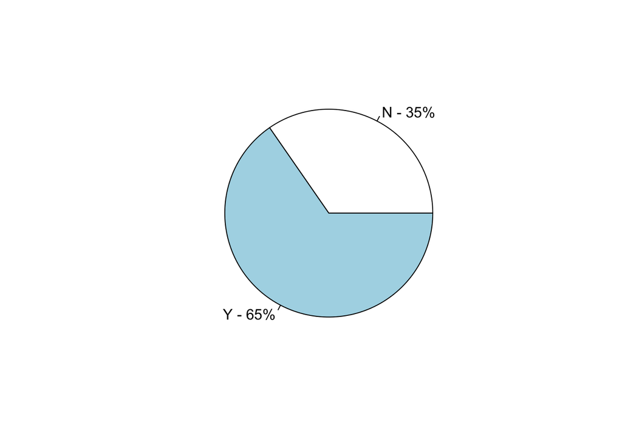

The resolution rate is about 65%.

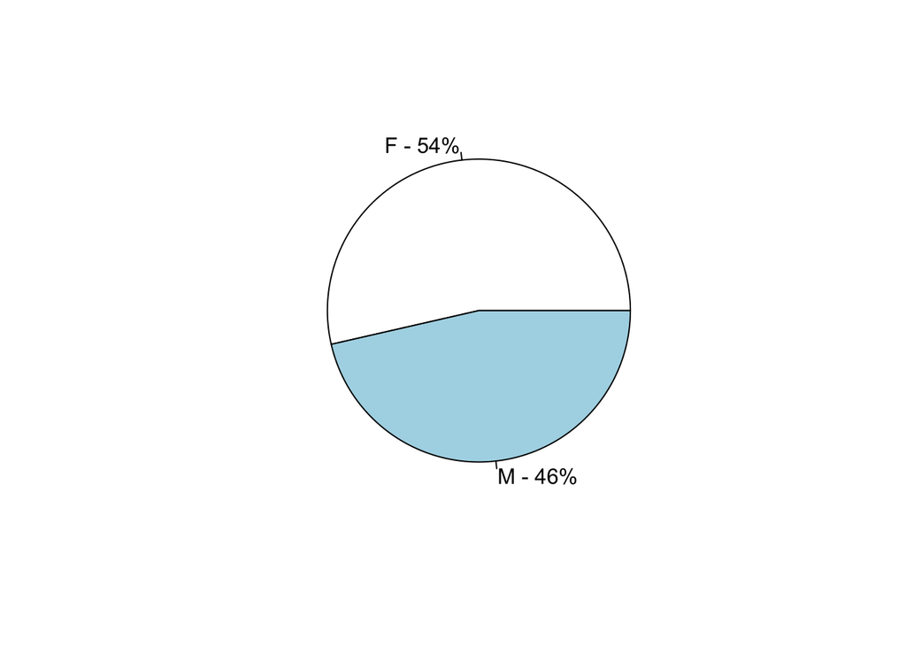

54% of complaints came from women vs 46% from men.

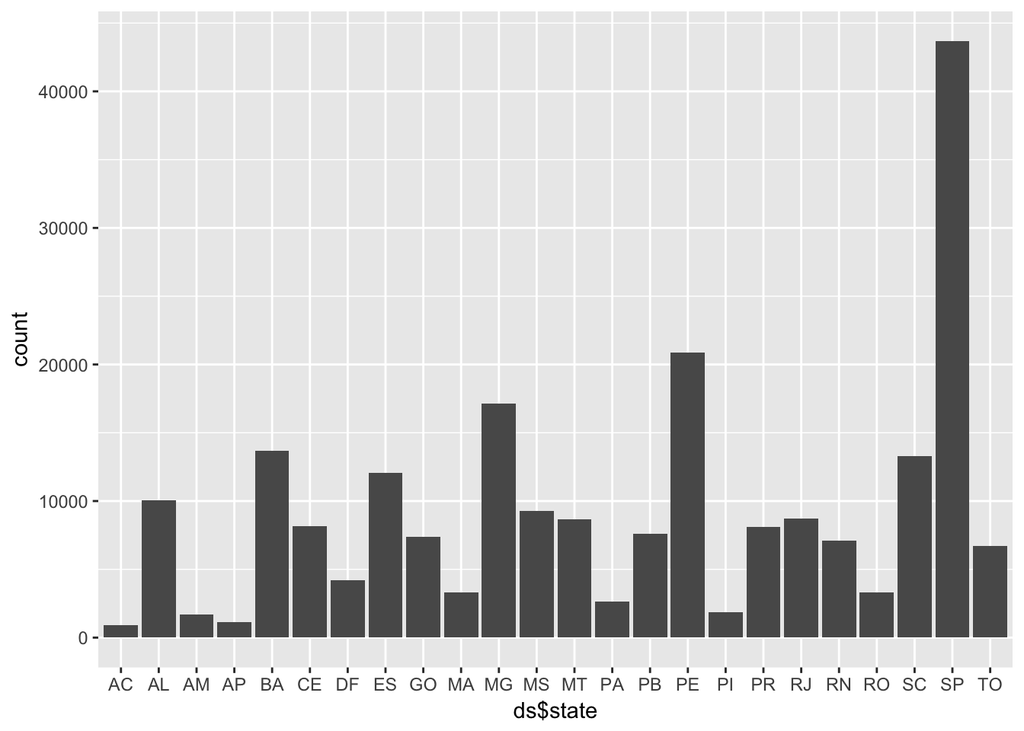

The state with most complaints is São Paulo (SP).

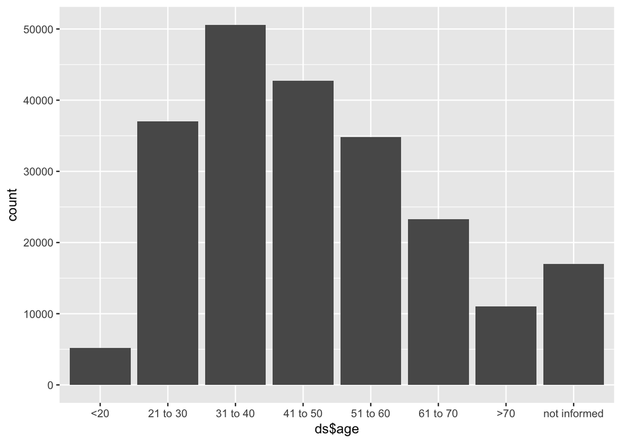

Most complaints are made by people between 31 and 40 years old.

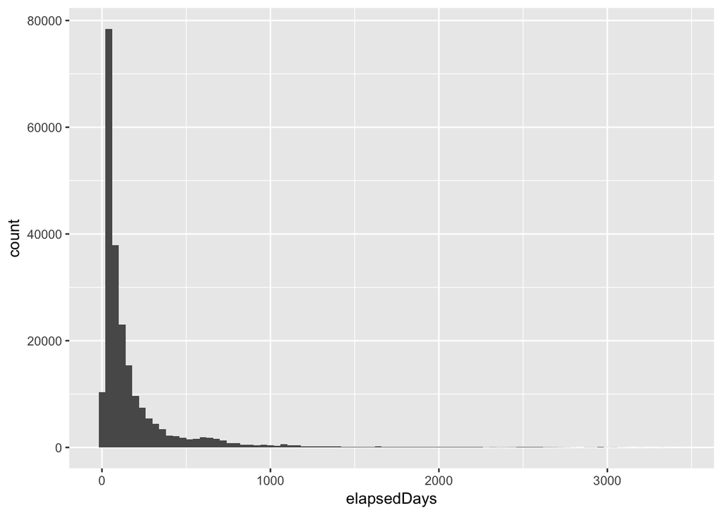

The number of days to close an issue has a long tail.

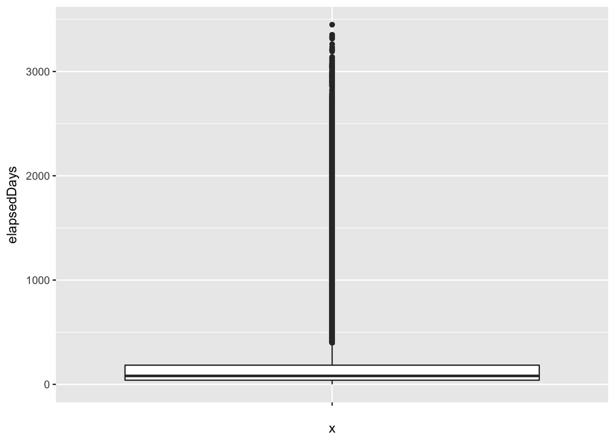

The number of days to close an issue has many outliers (11%).

```
## [1] 0.112612
```

# Univariate Analysis

### What is the structure of your dataset?

After cleaning missing values, removing columns not used in this analysis and adding a new one, the dataset contains around 221k complaints and 10 variables.

```r
dim(ds)
```

```
## [1] 221575     10
```

### What is/are the main feature(s) of interest in your dataset?

The main feature is *“resolved”* which indicates if the complaint was resolved with the company.

### What other features in the dataset do you think will help support your investigation into your feature(s) of interest?

Categorical features like gender, state, age, etc.

### Did you create any new variables from existing variables in the dataset?

Yes. I calculated the elapsed time in days between the registration date and the closing date.

### Of the features you investigated, were there any unusual distributions? Did you perform any operations on the data to tidy, adjust, or change the form of the data? If so, why did you do this?

I did some basic data wrangling in the company name so it can be counted correctly.

# Bivariate Plots Section

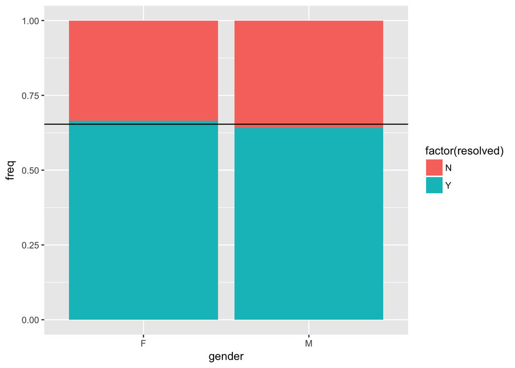

Men and women have practically the same chance to have their issues resolved.

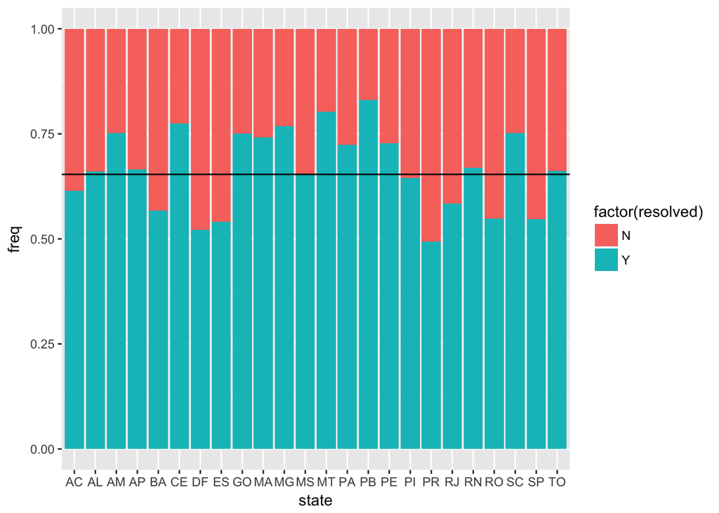

Consumers in some states have a much higher chance to resolve their issues.

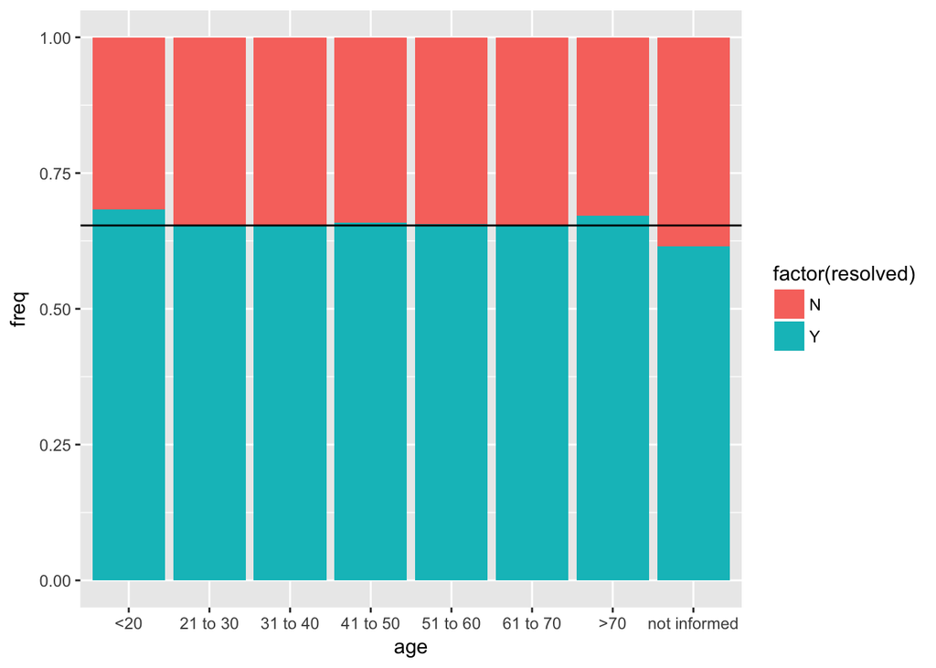

All age ranges have practically the same resolution rate around 65%, with a small advantage to under 20 (68%) and over 70 (67%). When the age is not informed, the resolution rate is smaller (~61%).

| companyName | N | Y | freq |
| --- | --- | --- | --- |
| OI S/A | 1190 | 5457 | 0.8209719 |
| CLARO S/A | 1459 | 4386 | 0.7503849 |
| TELEMAR NORTE LESTE S/A | 953 | 4231 | 0.8161651 |
| TIM CELULAR S/A | 1188 | 3290 | 0.7347030 |
| VIA VAREJO S/A | 915 | 2324 | 0.7175054 |
| SKY BRASIL SERVIÇOS LTDA | 886 | 2108 | 0.7040748 |
| TELEFONICA BRASIL S/A | 1043 | 1951 | 0.6516366 |
| CAIXA ECONMICA FEDERAL | 780 | 1656 | 0.6798030 |
| SKY BRASIL SERVIOS LTDA | 769 | 1584 | 0.6731832 |
| SAMSUNG ELETRONICA DA AMAZONIA LTDA | 552 | 1740 | 0.7591623 |

Resolution rate for the top 10 most frequent companies. OI S/A is the company with most complaints but also has a very high resolution rate.

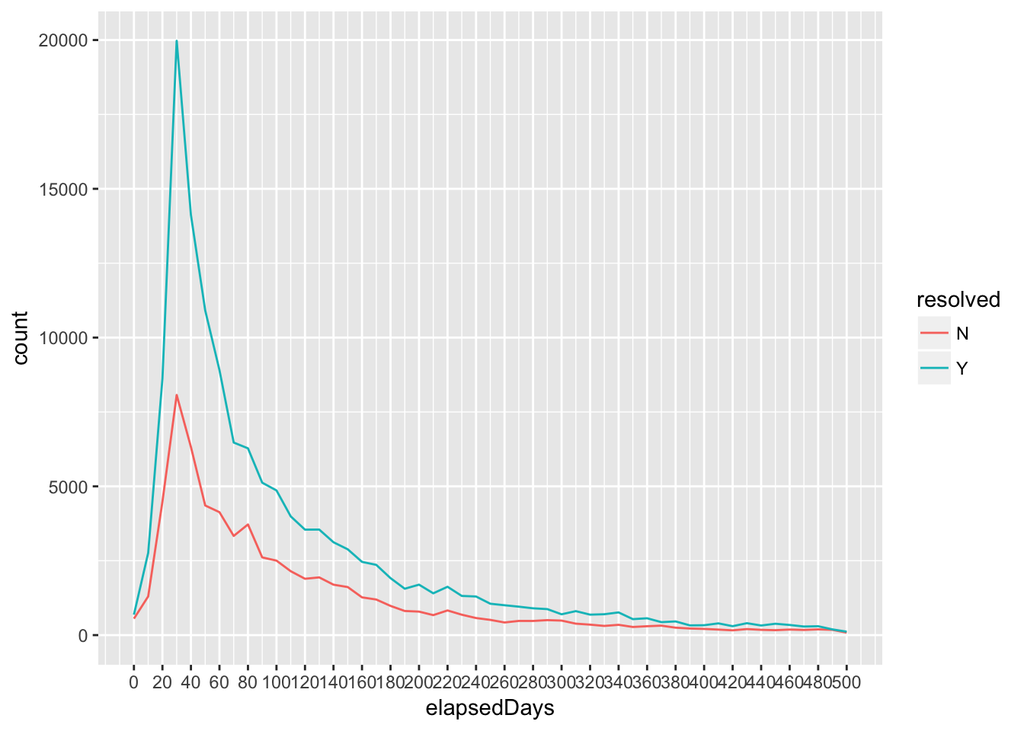

The shape of the distribution of the number of days to close an issue doesn’t change if the issue was resolved or not.

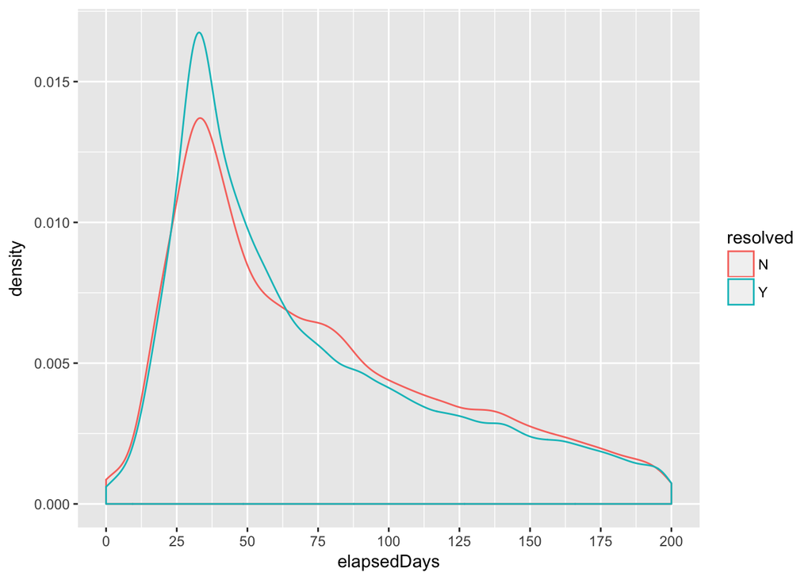

The issue has a better chance to be resolved between 25 and 60 days after its registration date. The resolution rate in this interval is 70%.

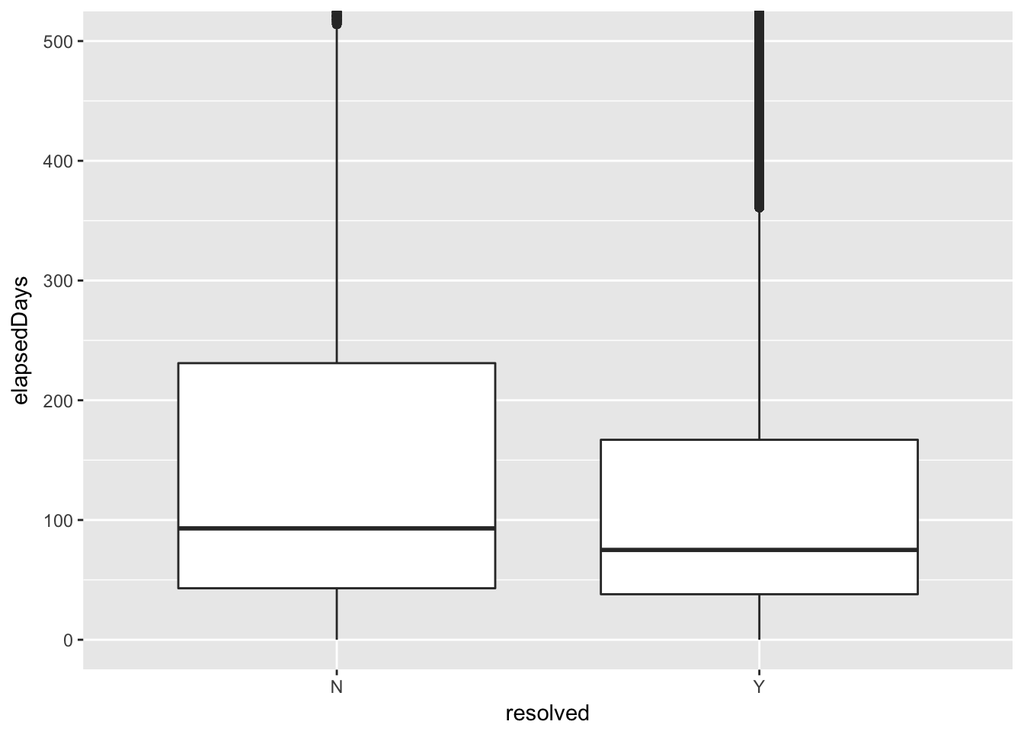

Resolved issues are closed more quickly than unresolved issues. The resolved issues have a median of 75 days versus 93 days of unresolved issues.

```
## ds$resolved: N
##    Min. 1st Qu.  Median    Mean 3rd Qu.    Max.
##     0.0    43.0    93.0   249.3   231.0  3449.0
## --------------------------------------------------------
## ds$resolved: Y
##    Min. 1st Qu.  Median    Mean 3rd Qu.    Max.
##     0.0    38.0    75.0   155.1   167.0  3316.0
```

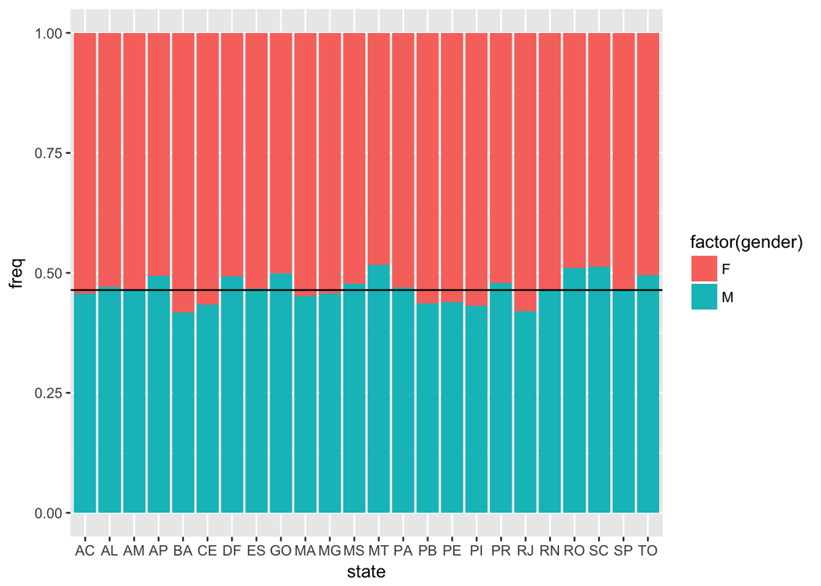

Women and men complaints per state are uniformly distributed.

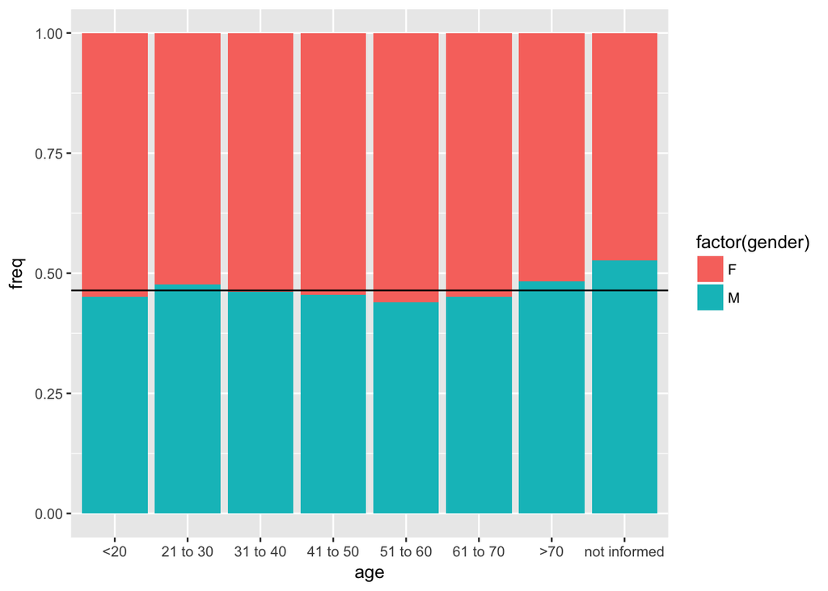

# Bivariate Analysis

### Talk about some of the relationships you observed in this part of the investigation. How did the feature(s) of interest vary with other features in the dataset?

The resolution rate varies a lot depending on the state and the number of days it takes to close the complaint.

### Did you observe any interesting relationships between the other features (not the main feature(s) of interest)?

The median time to resolve an issue varies a lot state by state.

### What was the strongest relationship you found?

The state where the complaint was filed has a strong impact on the resolution rate.

# Multivariate Plots Section

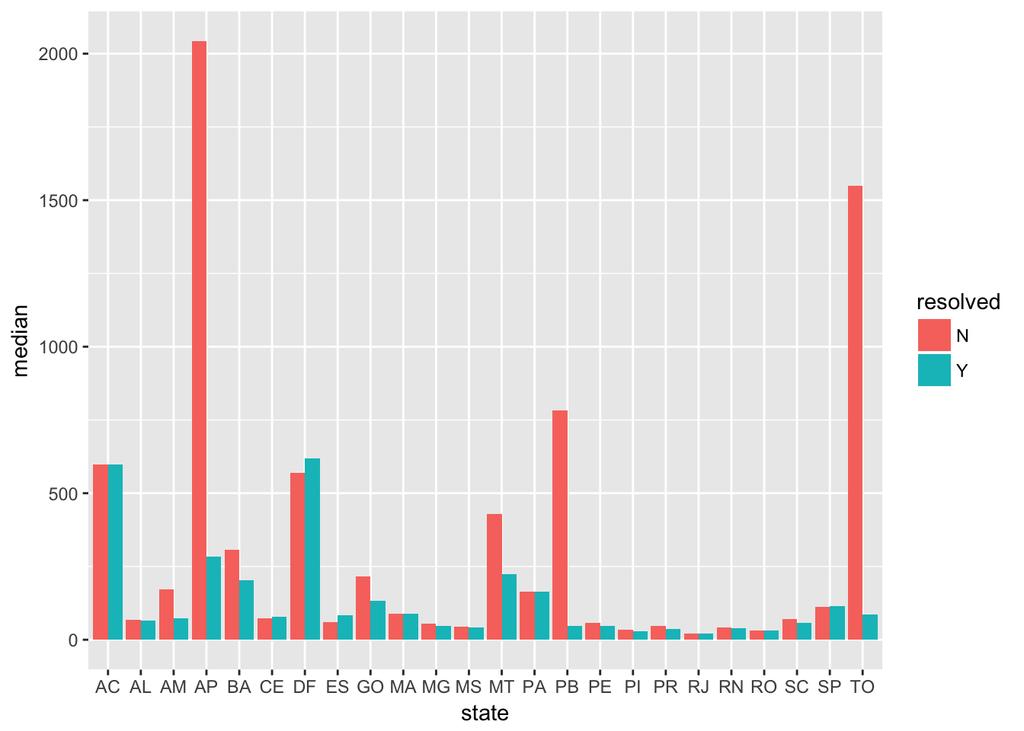

The median time to close an issue in some states (e.g. AP, PB and TO) have a huge difference when the issue was resolved or not.

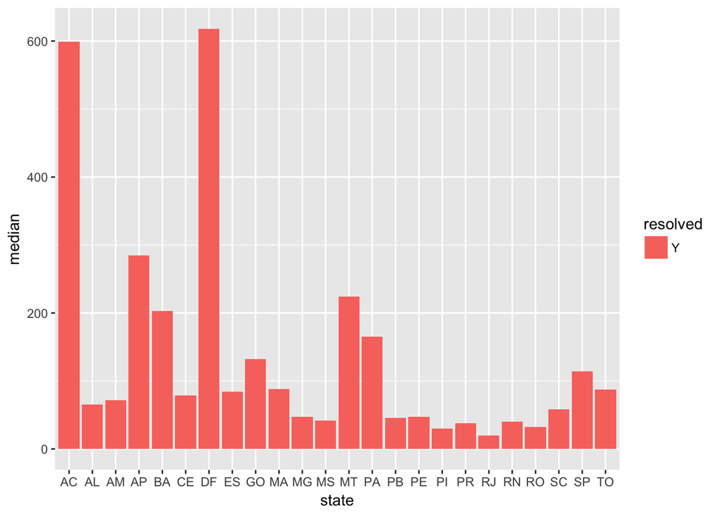

Observing only resolved issues, we can have a better sense of the median time to resolve an issue on different states. Some states have much worse median time than others.

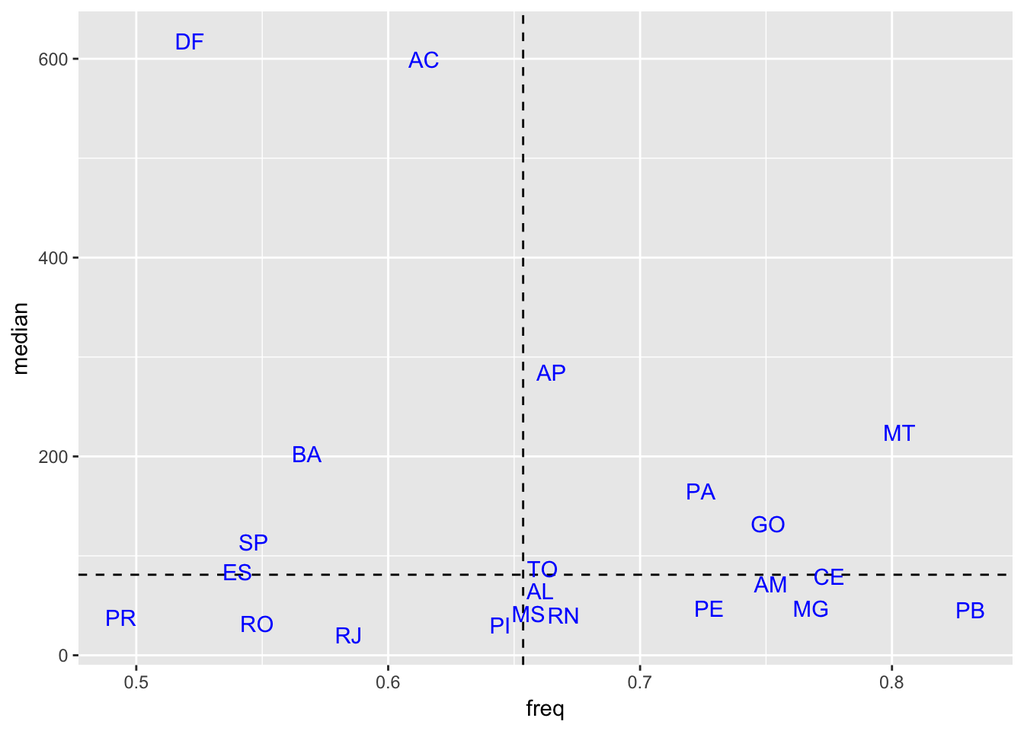

This plot compares the resolution rate and the median time to resolve an issue for each state. The horizontal dashed line represents the median interval between all states and the vertical line represents the general resolution rate. The chart could be divided into four quadrants:

| Quadrant | Resolution Rate | Median interval |
| --- | --- | --- |
| Bottom left | Low | Fast |
| Bottom right | High | Fast |
| Upper left | Low | Slow |
| Upper right | High | Slow |

The best quadrant is the bottom right and the worst is the upper left.

# Multivariate Analysis

### Talk about some of the relationships you observed in this part of the investigation. Were there features that strengthened each other in terms of looking at your feature(s) of interest?

The median time to resolve an issue doesn’t have a direct correlation with the resolution rate. Some states are fast to resolve an issue but have a small resolution rate (e.g. PR). Other states are fast and have a high resolution rate (e.g. PB). Some states are slow and have a small resolution rate (e.g. DF).

### Were there any interesting or surprising interactions between features?

Some states have a huge difference between the elapsed time of resolved and not resolved issues.

# Final Plots and Summary

### Resolution rate per state

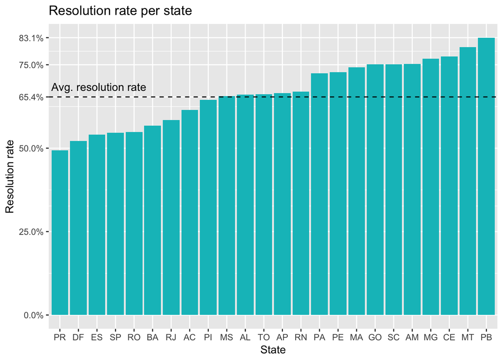

The state where the complaint was filed has a big impact on the chance to it be resolved. The difference between the best resolution rate (in PB) and the worst (in PR) is 33%.

### Median interval to resolve an issue per state

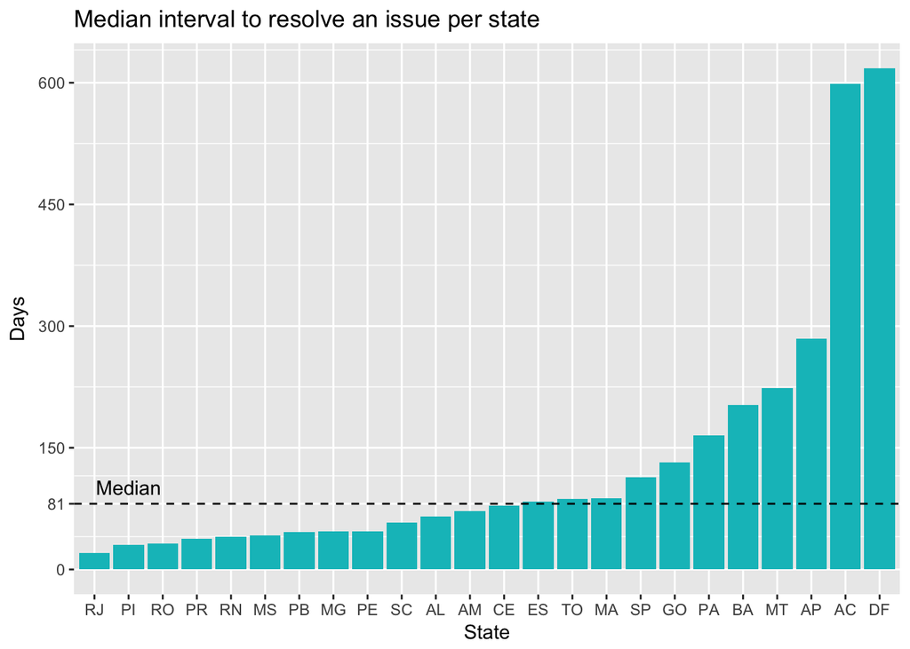

Different states vary a lot the median time to resolve an issue. Acre (AC) and Distrito Federal (DF) have median time close to 600 days. While Rio de Janeiro (RJ) and Piaui (PI) have the median time of 20 and 30 days respectively.

### Plot Three

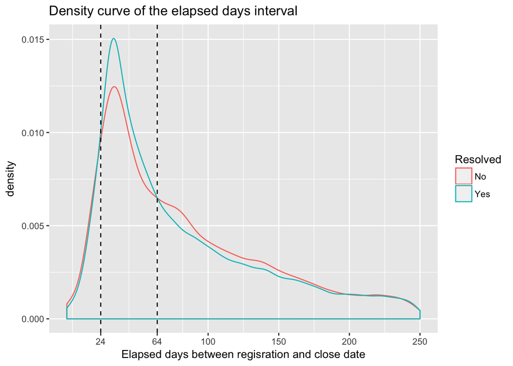

The chart above shows that the interval between 24 and 64 days has a greater density of resolved issues, i.e. the resolution rate is greater, as can be observed in the table below:

| elapsedDaysIntervals | freq |
| --- | --- |
| [0,25] | 0.6553936 |
| (25,64] | 0.7025362 |
| (64,1e+04] | 0.6241736 |

This information will help to build a predictive model in a future work.

# Reflection

This exploratory analysis gave an overview of the performance of Procons in different states. For example, in Brasilia, capital of Brazil, the Procon has a very poor performance in both the resolution rate (second worst) and the time it took to resolve an issue (almost 2 years).

Ideas for the future:

- Use data from other years to analyze trends in data.
- Come up with an indicator of the quality of the Procon considering the resolution rate and the time it takes to resolve the issue.
- Come up with an indicator for the companies.
- Come up with a predictive model to give the probability of an issue be resolved.

The worst data in the dataset was the name of the company because it came from user input and have a lot of typos. As the focus of the analysis was to compare the performance of the states, this was not a big issue.

A feature missing in the dataset is the address of the Procon where the issue was filed. This might help to identify the culprint for poor performance in the states.